# Project: Investigate a TMDB Dataset

- Introduction
- Data Wrangling
- Exploratory Data Analysis
- Conclusions

## Introduction

In this project of Data Analysis, I am investigating a TMDb movies database file which has collection of important detials of about 10k+ movies, including their details of budget, revenue, release dates, etc.  
Questions:  
1.WHAT IS THE AVERAGE RUNTIME OF MOVIES?  
2.WHICH MOVIE GENRES ARE MOST POPULAR?  
3.WHAT MONTH IS CONSIDERED BEST FOR RELEASING A FILM??

```python
import numpy as np
import pandas as pd
import seaborn as sns
import matplotlib.pyplot as ml
% matplotlib inline
```

## Data Wrangling

### General Properties

In this section we will take an initial view of the data - this will also include the number of rows, the datatypes and the number of non-null values in those columns. We will also take a look at the number of unique values for those columns.

```python
df=pd.read_csv('tmdb-movies.csv')
df.head()
```

|  | id | imdb_id | popularity | budget | revenue | original_title | cast | homepage | director | tagline | ... | overview | runtime | genres | production_companies | release_date | vote_count | vote_average | release_year | budget_adj | revenue_adj |
| --- | --- | --- | --- | --- | --- | --- | --- | --- | --- | --- | --- | --- | --- | --- | --- | --- | --- | --- | --- | --- | --- |
| 0 | 135397 | tt0369610 | 32.985763 | 150000000 | 1513528810 | Jurassic World | Chris Pratt\|Bryce Dallas Howard\|Irrfan Khan\|Vi... | http://www.jurassicworld.com/ | Colin Trevorrow | The park is open. | ... | Twenty-two years after the events of Jurassic ... | 124 | Action\|Adventure\|Science Fiction\|Thriller | Universal Studios\|Amblin Entertainment\|Legenda... | 6/9/15 | 5562 | 6.5 | 2015 | 1.379999e+08 | 1.392446e+09 |
| 1 | 76341 | tt1392190 | 28.419936 | 150000000 | 378436354 | Mad Max: Fury Road | Tom Hardy\|Charlize Theron\|Hugh Keays-Byrne\|Nic... | http://www.madmaxmovie.com/ | George Miller | What a Lovely Day. | ... | An apocalyptic story set in the furthest reach... | 120 | Action\|Adventure\|Science Fiction\|Thriller | Village Roadshow Pictures\|Kennedy Miller Produ... | 5/13/15 | 6185 | 7.1 | 2015 | 1.379999e+08 | 3.481613e+08 |
| 2 | 262500 | tt2908446 | 13.112507 | 110000000 | 295238201 | Insurgent | Shailene Woodley\|Theo James\|Kate Winslet\|Ansel... | http://www.thedivergentseries.movie/#insurgent | Robert Schwentke | One Choice Can Destroy You | ... | Beatrice Prior must confront her inner demons ... | 119 | Adventure\|Science Fiction\|Thriller | Summit Entertainment\|Mandeville Films\|Red Wago... | 3/18/15 | 2480 | 6.3 | 2015 | 1.012000e+08 | 2.716190e+08 |
| 3 | 140607 | tt2488496 | 11.173104 | 200000000 | 2068178225 | Star Wars: The Force Awakens | Harrison Ford\|Mark Hamill\|Carrie Fisher\|Adam D... | http://www.starwars.com/films/star-wars-episod... | J.J. Abrams | Every generation has a story. | ... | Thirty years after defeating the Galactic Empi... | 136 | Action\|Adventure\|Science Fiction\|Fantasy | Lucasfilm\|Truenorth Productions\|Bad Robot | 12/15/15 | 5292 | 7.5 | 2015 | 1.839999e+08 | 1.902723e+09 |
| 4 | 168259 | tt2820852 | 9.335014 | 190000000 | 1506249360 | Furious 7 | Vin Diesel\|Paul Walker\|Jason Statham\|Michelle ... | http://www.furious7.com/ | James Wan | Vengeance Hits Home | ... | Deckard Shaw seeks revenge against Dominic Tor... | 137 | Action\|Crime\|Thriller | Universal Pictures\|Original Film\|Media Rights ... | 4/1/15 | 2947 | 7.3 | 2015 | 1.747999e+08 | 1.385749e+09 |

5 rows × 21 columns

```python
df.info()
```

```
<class 'pandas.core.frame.DataFrame'>
RangeIndex: 10866 entries, 0 to 10865
Data columns (total 21 columns):
id                      10866 non-null int64
imdb_id                 10856 non-null object
popularity              10866 non-null float64
budget                  10866 non-null int64
revenue                 10866 non-null int64
original_title          10866 non-null object
cast                    10790 non-null object
homepage                2936 non-null object
director                10822 non-null object
tagline                 8042 non-null object
keywords                9373 non-null object
overview                10862 non-null object
runtime                 10866 non-null int64
genres                  10843 non-null object
production_companies    9836 non-null object
release_date            10866 non-null object
vote_count              10866 non-null int64
vote_average            10866 non-null float64
release_year            10866 non-null int64
budget_adj              10866 non-null float64
revenue_adj             10866 non-null float64
dtypes: float64(4), int64(6), object(11)
memory usage: 1.7+ MB
```

### Data Cleaning(Removing the unused information from the dataset)

After discussing the structure of the data and any problems that need to be cleaned,the cleaning steps are performed in this section.

Here, we need to drop some columns which are extraneous to the questions in our analysis.like imdb_id,homepage,keywords,overview,vote_count,vote_average are no longer necessary columns for our data analysis.So we drop them.

```python
col=['imdb_id','budget_adj', 'revenue_adj', 'homepage', 'keywords', 'overview', 'production_companies', 'vote_count', 'vote_average']
df=df.drop(col,1)
df.head(5)
```

|  | id | popularity | budget | revenue | original_title | cast | director | tagline | runtime | genres | release_date | release_year |
| --- | --- | --- | --- | --- | --- | --- | --- | --- | --- | --- | --- | --- |
| 0 | 135397 | 32.985763 | 150000000 | 1513528810 | Jurassic World | Chris Pratt\|Bryce Dallas Howard\|Irrfan Khan\|Vi... | Colin Trevorrow | The park is open. | 124 | Action\|Adventure\|Science Fiction\|Thriller | 6/9/15 | 2015 |
| 1 | 76341 | 28.419936 | 150000000 | 378436354 | Mad Max: Fury Road | Tom Hardy\|Charlize Theron\|Hugh Keays-Byrne\|Nic... | George Miller | What a Lovely Day. | 120 | Action\|Adventure\|Science Fiction\|Thriller | 5/13/15 | 2015 |
| 2 | 262500 | 13.112507 | 110000000 | 295238201 | Insurgent | Shailene Woodley\|Theo James\|Kate Winslet\|Ansel... | Robert Schwentke | One Choice Can Destroy You | 119 | Adventure\|Science Fiction\|Thriller | 3/18/15 | 2015 |
| 3 | 140607 | 11.173104 | 200000000 | 2068178225 | Star Wars: The Force Awakens | Harrison Ford\|Mark Hamill\|Carrie Fisher\|Adam D... | J.J. Abrams | Every generation has a story. | 136 | Action\|Adventure\|Science Fiction\|Fantasy | 12/15/15 | 2015 |
| 4 | 168259 | 9.335014 | 190000000 | 1506249360 | Furious 7 | Vin Diesel\|Paul Walker\|Jason Statham\|Michelle ... | James Wan | Vengeance Hits Home | 137 | Action\|Crime\|Thriller | 4/1/15 | 2015 |

Now,removing duplicate rows if any.

```python
df.drop_duplicates(keep='first',inplace=True)
rows,cols=df.shape
df.shape
```

```
(10865, 12)
```

```python
tlist=['budget', 'revenue','runtime','release_year']
df[tlist] = df[tlist].replace(0, np.NAN)
df.dropna(subset = tlist, inplace = True)
rows, cols = df.shape
print('{}'.format(rows-1))
```

```
3853
```

There was a duplicate row which has been removed now.

Changing the release date column into standard date format:

```python
df.release_date = pd.to_datetime(df['release_date'])
df.head(5)
```

|  | id | popularity | budget | revenue | original_title | cast | director | tagline | runtime | genres | release_date | release_year |
| --- | --- | --- | --- | --- | --- | --- | --- | --- | --- | --- | --- | --- |
| 0 | 135397 | 32.985763 | 150000000.0 | 1.513529e+09 | Jurassic World | Chris Pratt\|Bryce Dallas Howard\|Irrfan Khan\|Vi... | Colin Trevorrow | The park is open. | 124.0 | Action\|Adventure\|Science Fiction\|Thriller | 2015-06-09 | 2015 |
| 1 | 76341 | 28.419936 | 150000000.0 | 3.784364e+08 | Mad Max: Fury Road | Tom Hardy\|Charlize Theron\|Hugh Keays-Byrne\|Nic... | George Miller | What a Lovely Day. | 120.0 | Action\|Adventure\|Science Fiction\|Thriller | 2015-05-13 | 2015 |
| 2 | 262500 | 13.112507 | 110000000.0 | 2.952382e+08 | Insurgent | Shailene Woodley\|Theo James\|Kate Winslet\|Ansel... | Robert Schwentke | One Choice Can Destroy You | 119.0 | Adventure\|Science Fiction\|Thriller | 2015-03-18 | 2015 |
| 3 | 140607 | 11.173104 | 200000000.0 | 2.068178e+09 | Star Wars: The Force Awakens | Harrison Ford\|Mark Hamill\|Carrie Fisher\|Adam D... | J.J. Abrams | Every generation has a story. | 136.0 | Action\|Adventure\|Science Fiction\|Fantasy | 2015-12-15 | 2015 |
| 4 | 168259 | 9.335014 | 190000000.0 | 1.506249e+09 | Furious 7 | Vin Diesel\|Paul Walker\|Jason Statham\|Michelle ... | James Wan | Vengeance Hits Home | 137.0 | Action\|Crime\|Thriller | 2015-04-01 | 2015 |

## Exploratory Data Analysis

## Research Question 1

### WHAT IS THE AVERAGE RUNTIME OF MOVIES?

```python
#defining a function to calculate average of a column
def avg_fun(column):
    return df[column].mean()
#calling the function
avg_fun('runtime')
```

```
109.22029060716139
```

Hence, the average runtime of the movies is 109 minutes. Now we will represent it in a graphical form.

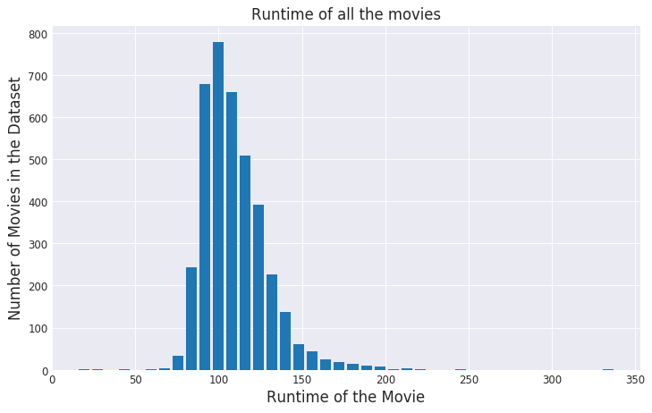

```python
#plotting a histogram for the average runtime of the movies

#mentioning figure size(height,width)
ml.figure(figsize=(10,6), dpi = 85)
#x-axis
ml.xlabel('Runtime of the Movie', fontsize = 14)
#y-axis
ml.ylabel('Number of Movies in the Dataset', fontsize=14)
#name of the histogram
ml.title('Runtime of all the movies', fontsize=14)
#plotting the histogram
ml.hist(df['runtime'], rwidth = 0.8, bins =40)
ml.show()
```

```python
ml.figure(figsize=(10,5), dpi = 105)
#using seaborn to generate the plot
sns.swarmplot(df['runtime'], color = 'black')
#displaying the plot
ml.show()
```

[output not shown]

```python
#The First plot is box plot of the runtime of the movies
ml.figure(figsize=(9,7), dpi = 105)

#using seaborn to generate the boxplot
sns.boxplot(df['runtime'], linewidth = 3)
#diplaying the plot
ml.show()
```

[output not shown]